# Practical Machine Learning Project

FJF

Wednesday, October 22, 2014

### Introduction

Source of data: “Human Activity Recognition” http://groupware.les.inf.puc-rio.br/har

#### Step 1: Get full dataset

For ease of use, we work with a downloaded copy of the data.

```r
# url= "https://d396qusza40orc.cloudfront.net/predmachlearn/pml-training.csv"
destfile = "PML Wearable.csv"
# download.file(url, destfile)
# training = read.csv(url)
training = read.csv(destfile)
dim0 = dim(training)  # 19622 obs, 160 variables
dim0
```

```
## [1] 19622   160
```

#### Step 1B: Create cross-validation set

In order to estimate the “out-of-sample error”, we split 20% of the given training set to create a cross validation (CV) set and we use the remaining 80% as the proper training set.

```r
library(caret, verbose=F)
cvIndex = createDataPartition(training$classe,
                                p = 0.20,list=FALSE)  # create CV indices
train0 = training[-cvIndex,]                          # select training
cv0 = training[cvIndex,]                              # select CV
dim(train0);dim(cv0)                                  # check dimensions
```

```
[1] 15695   160
```

```
[1] 3927  160
```

#### Step 2: Remove NA-variables and other unrelated or problematic variables

We see that the outcome (classe) is grouped by the observation number (X) Therefore we need to exclude X from all inference attempts. Also we will exclude the timestamps.

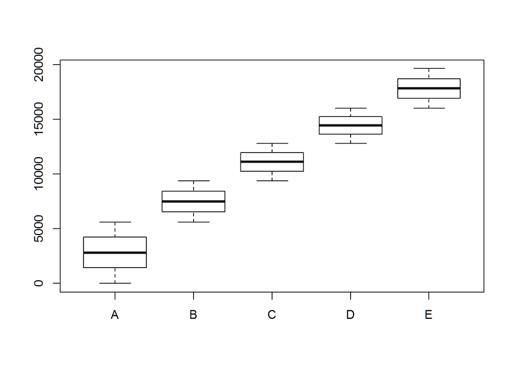

```r
# observations are sorted by classe
boxplot(X ~ classe, data=train0)
```

```r
dim0 = dim(train0)

ex1 = sapply(train0, function(x) sum(is.na(x)))    # count NA per variable                                                # we see 0 or high counts
ex2 = which(ex1 > 0)                    # get indices
options(width=100)
ex2
```

```
           max_roll_belt           max_picth_belt            min_roll_belt           min_pitch_belt
                      18                       19                       21                       22
     amplitude_roll_belt     amplitude_pitch_belt     var_total_accel_belt            avg_roll_belt
                      24                       25                       27                       28
        stddev_roll_belt            var_roll_belt           avg_pitch_belt        stddev_pitch_belt
                      29                       30                       31                       32
          var_pitch_belt             avg_yaw_belt          stddev_yaw_belt             var_yaw_belt
                      33                       34                       35                       36
           var_accel_arm             avg_roll_arm          stddev_roll_arm             var_roll_arm
                      50                       51                       52                       53
           avg_pitch_arm         stddev_pitch_arm            var_pitch_arm              avg_yaw_arm
                      54                       55                       56                       57
          stddev_yaw_arm              var_yaw_arm             max_roll_arm            max_picth_arm
                      58                       59                       75                       76
             max_yaw_arm             min_roll_arm            min_pitch_arm              min_yaw_arm
                      77                       78                       79                       80
      amplitude_roll_arm      amplitude_pitch_arm        amplitude_yaw_arm        max_roll_dumbbell
                      81                       82                       83                       93
      max_picth_dumbbell        min_roll_dumbbell       min_pitch_dumbbell  amplitude_roll_dumbbell
                      94                       96                       97                       99
amplitude_pitch_dumbbell       var_accel_dumbbell        avg_roll_dumbbell     stddev_roll_dumbbell
                     100                      103                      104                      105
       var_roll_dumbbell       avg_pitch_dumbbell    stddev_pitch_dumbbell       var_pitch_dumbbell
                     106                      107                      108                      109
        avg_yaw_dumbbell      stddev_yaw_dumbbell         var_yaw_dumbbell         max_roll_forearm
                     110                      111                      112                      131
       max_picth_forearm         min_roll_forearm        min_pitch_forearm   amplitude_roll_forearm
                     132                      134                      135                      137
 amplitude_pitch_forearm        var_accel_forearm         avg_roll_forearm      stddev_roll_forearm
                     138                      141                      142                      143
        var_roll_forearm        avg_pitch_forearm     stddev_pitch_forearm        var_pitch_forearm
                     144                      145                      146                      147
         avg_yaw_forearm       stddev_yaw_forearm          var_yaw_forearm
                     148                      149                      150
```

```r
ex2 = as.vector(ex2)
# create training set with exclusion of highly NA variables
train2 = train0[,-ex2]                             # remove NA-variables
train2 = train2[,-(1:7)]    # remove first 7 variables
dim2 = dim(train2)
```

#### Step 3: Remove highly correlated numerical variables

We check each pair of numerical variables for a corrleation with absolute value > 0.8. In such a case, we mark the second variable for removal and we do not check that second variable for further correlations.

```r
elim = c()                  # collect variables to be eliminated
for (i1 in 1:dim2[[2]])     # loop over all variables
    {
        if (i1 %in% elim)   # skip if already eliminated
            next;
        cl1 = class(train2[[i1]])         # check class for numeric
        check_num1 = (cl1 %in% c("integer", "numeric"))
        if (!check_num1)  next;
        for (i2 in (i1+1):dim2[[2]])     # check against further var
            {
                if (i2 %in% elim)  next;
                cl2 = class(train2[[i2]])
                check_num2 = (cl2 %in% c("integer", "numeric"))
                if (!check_num2)  next;
                r = cor(train2[[i1]], train2[[i2]])
                if (abs(r) <= 0.8)  next;
                name1 = names(train2)[i1]
                name2 = names(train2)[i2]
                cat("\n i1=",i1, "=",names(train2)[i1],
                    "  i2=", i2, "=",names(train2)[i2],
                    "   cor=", cor(train2[[i1]], train2[[i2]]))
                elim = c(elim, i2)
            } # inner loop
    } # outer loop
```

```
 i1= 1 = roll_belt   i2= 3 = yaw_belt    cor= 0.8152
 i1= 1 = roll_belt   i2= 4 = total_accel_belt    cor= 0.9811
 i1= 1 = roll_belt   i2= 18 = accel_belt_y    cor= 0.9236
 i1= 1 = roll_belt   i2= 19 = accel_belt_z    cor= -0.992
 i1= 2 = pitch_belt   i2= 17 = accel_belt_x    cor= -0.965
 i1= 2 = pitch_belt   i2= 20 = magnet_belt_x    cor= -0.8806
 i1= 27 = gyros_arm_x   i2= 28 = gyros_arm_y    cor= -0.9183
 i1= 30 = accel_arm_x   i2= 33 = magnet_arm_x    cor= 0.8168
 i1= 34 = magnet_arm_y   i2= 35 = magnet_arm_z    cor= 0.8132
 i1= 43 = pitch_dumbbell   i2= 58 = accel_dumbbell_x    cor= 0.8069
 i1= 44 = yaw_dumbbell   i2= 60 = accel_dumbbell_z    cor= 0.8482
 i1= 55 = gyros_dumbbell_x   i2= 57 = gyros_dumbbell_z    cor= -0.9831
 i1= 55 = gyros_dumbbell_x   i2= 79 = gyros_forearm_z    cor= -0.9305
```

```r
train3 = train2[,-elim]           # remove highly correlated variables
dim3 = dim(train3)
```

#### Step 4: Check factorial variables

We check factorial variables for  
(1) independence from variable “classe” (with chi-squared-test)  
(2) proportion of the most frequent value

Factorial variables which are pretty much independen from the outcome variable “classe”“, can be removed. Also We eliminate all variables which have a very dominating single value, because we cannot expect them to contribute to the model.

```r
elimf = c()
for (i in 1:dim3[[2]])
    {
        namei = names(train3)[i]
        classi = class(train3[[i]])
        if (classi == "factor")
            {
                tf = table(train3[[i]])
                num_lev = length(tf)
                cat("\n i=", i,"  name=", names(train3)[[i]],
                    "  levels=", num_lev)
                max_tf = max(tf)
                if (max_tf / dim3[[1]] > 0.5 )
                {
                        cat("   maximum frequency =", max_tf, "\n")
                        elimf = c(elimf, i)
                        next
                }
                if (num_lev <= 100)
                    {
                    tf2 = table(train3[[i]], train3$classe)
                    ct = chisq.test(tf2)
                    if (ct$p.value > 0.5)
                        {
                            cat("chisq-test p-value=",ct$p.value, "\n")
                            print(ct)  # chisq-test
                            elimf = c(elimf, i)
                        }
                    }
                } # factor
    } # loop
```

```
 i= 3   name= kurtosis_roll_belt   levels= 397   maximum frequency = 15358

 i= 4   name= kurtosis_picth_belt   levels= 317   maximum frequency = 15358

 i= 5   name= kurtosis_yaw_belt   levels= 2   maximum frequency = 15358

 i= 6   name= skewness_roll_belt   levels= 395   maximum frequency = 15358

 i= 7   name= skewness_roll_belt.1   levels= 338   maximum frequency = 15358

 i= 8   name= skewness_yaw_belt   levels= 2   maximum frequency = 15358

 i= 9   name= max_yaw_belt   levels= 68   maximum frequency = 15358

 i= 10   name= min_yaw_belt   levels= 68   maximum frequency = 15358

 i= 11   name= amplitude_yaw_belt   levels= 4   maximum frequency = 15358

 i= 27   name= kurtosis_roll_arm   levels= 330   maximum frequency = 15358

 i= 28   name= kurtosis_picth_arm   levels= 328   maximum frequency = 15358

 i= 29   name= kurtosis_yaw_arm   levels= 395   maximum frequency = 15358

 i= 30   name= skewness_roll_arm   levels= 331   maximum frequency = 15358

 i= 31   name= skewness_pitch_arm   levels= 328   maximum frequency = 15358

 i= 32   name= skewness_yaw_arm   levels= 395   maximum frequency = 15358

 i= 36   name= kurtosis_roll_dumbbell   levels= 398   maximum frequency = 15358

 i= 37   name= kurtosis_picth_dumbbell   levels= 401   maximum frequency = 15358

 i= 38   name= kurtosis_yaw_dumbbell   levels= 2   maximum frequency = 15358

 i= 39   name= skewness_roll_dumbbell   levels= 401   maximum frequency = 15358

 i= 40   name= skewness_pitch_dumbbell   levels= 402   maximum frequency = 15358

```

[output cut: 12 more lines]

```
 i= 57   name= kurtosis_yaw_forearm   levels= 2   maximum frequency = 15358

 i= 58   name= skewness_roll_forearm   levels= 323   maximum frequency = 15358

 i= 59   name= skewness_pitch_forearm   levels= 319   maximum frequency = 15358

 i= 60   name= skewness_yaw_forearm   levels= 2   maximum frequency = 15358

 i= 61   name= max_yaw_forearm   levels= 45   maximum frequency = 15358

 i= 62   name= min_yaw_forearm   levels= 45   maximum frequency = 15358

 i= 63   name= amplitude_yaw_forearm   levels= 3   maximum frequency = 15358

 i= 73   name= classe   levels= 5
```

```r
train4 = train3[,-elimf]
dim4 = dim(train4)
dim4                    # remaining: 40 variables
```

```
[1] 15695    40
```

#### Step 5: Prediction with Random Forest

We use a Random Forest prediction and PCA Pre-processing (as suggested in one of the lectures) Then we check the accuracy on the reduced training set and the separate cross validation set (cv0) The out-of-sample error can be estimated from the accuracy on the cv set.

```r
library(caret)

accuracy = function(predicted, observed)
    {
        ok = sum(predicted == observed)
        total = length(observed)
        ok/total   # accuracy
    }

# random forest
fit2 = train(classe ~.,
                  method="rf",
                  preProcess="pca",   # request pre-processing
                  data=train4)
fit2
```

```
Random Forest

15695 samples
   39 predictors
    5 classes: 'A', 'B', 'C', 'D', 'E'

Pre-processing: principal component signal extraction, scaled, centered
Resampling: Bootstrapped (25 reps)

Summary of sample sizes: 15695, 15695, 15695, 15695, 15695, 15695, ...

Resampling results across tuning parameters:

  mtry  Accuracy  Kappa  Accuracy SD  Kappa SD
  2     1         1      0.003        0.004
  20    1         0.9    0.005        0.006
  40    0.9       0.9    0.006        0.008

Accuracy was used to select the optimal model using  the largest value.
The final value used for the model was mtry = 2.
```

We see that we achieve a very high accuracy. The in-sample error is practically 0, but more importantly, the “out-of-band” error obtained from the final model, is about 2%.

```r
fit2.pred = predict(fit2, train4)    # predict for rf model
accuracy(fit2.pred, train4$classe)   # compare
```

```
[1] 1
```

```r
# statistics per class
confusionMatrix(train4$classe, fit2.pred)
```

```
Confusion Matrix and Statistics

          Reference
Prediction    A    B    C    D    E
         A 4464    0    0    0    0
         B    0 3037    0    0    0
         C    0    0 2737    0    0
         D    0    0    0 2572    0
         E    0    0    0    0 2885

Overall Statistics

               Accuracy : 1
                 95% CI : (1, 1)
    No Information Rate : 0.284
    P-Value [Acc > NIR] : <2e-16

                  Kappa : 1
 Mcnemar's Test P-Value : NA

Statistics by Class:

                     Class: A Class: B Class: C Class: D Class: E
Sensitivity             1.000    1.000    1.000    1.000    1.000
Specificity             1.000    1.000    1.000    1.000    1.000
Pos Pred Value          1.000    1.000    1.000    1.000    1.000
Neg Pred Value          1.000    1.000    1.000    1.000    1.000
Prevalence              0.284    0.194    0.174    0.164    0.184
Detection Rate          0.284    0.194    0.174    0.164    0.184
Detection Prevalence    0.284    0.194    0.174    0.164    0.184
Balanced Accuracy       1.000    1.000    1.000    1.000    1.000
```

```r
fit2$finalModel
```

```
Call:
 randomForest(x = x, y = y, mtry = param$mtry)
               Type of random forest: classification
                     Number of trees: 500
No. of variables tried at each split: 2

        OOB estimate of  error rate: 2.25%
Confusion matrix:
     A    B    C    D    E class.error
A 4429    9   18    7    1    0.007841
B   50 2949   34    2    2    0.028976
C    7   40 2669   19    2    0.024845
D    4    4  102 2458    4    0.044323
E    1    9   23   15 2837    0.016638
```

Finally we apply the prediction to the CV set and see that the accuracy is very high again. **We get the same “out of sample” error of about 2%.**

```r
# apply to cv set
fit2.pred.cv = predict(fit2, cv0)
accuracy(fit2.pred.cv, cv0$classe)   # 0.9765
```

```
[1] 0.9786
```

```r
confusionMatrix(cv0$classe, fit2.pred.cv)
```

```
Confusion Matrix and Statistics

          Reference
Prediction    A    B    C    D    E
         A 1112    1    3    0    0
         B    8  744    7    0    1
         C    0    9  671    5    0
         D    0    0   32  611    1
         E    0    4    8    5  705

Overall Statistics

               Accuracy : 0.979
                 95% CI : (0.974, 0.983)
    No Information Rate : 0.285
    P-Value [Acc > NIR] : <2e-16

                  Kappa : 0.973
 Mcnemar's Test P-Value : NA

Statistics by Class:

                     Class: A Class: B Class: C Class: D Class: E
Sensitivity             0.993    0.982    0.931    0.984    0.997
Specificity             0.999    0.995    0.996    0.990    0.995
Pos Pred Value          0.996    0.979    0.980    0.949    0.976
Neg Pred Value          0.997    0.996    0.985    0.997    0.999
Prevalence              0.285    0.193    0.184    0.158    0.180
Detection Rate          0.283    0.189    0.171    0.156    0.180
Detection Prevalence    0.284    0.194    0.174    0.164    0.184
Balanced Accuracy       0.996    0.988    0.963    0.987    0.996
```

#### Step 6: Apply to the 20 test cases

```r
# url_test = "https://d396qusza40orc.cloudfront.net/predmachlearn/pml-testing.csv"
destfile_test = "PML Wearable.test.csv"
# download.file(url_test, destfile_test)

test0 = read.csv(destfile_test)

fit2.test = predict(fit2, test0)

pml_write_files = function(x){
  n = length(x)
  for(i in 1:n){
    filename = paste0("Submit2/problem_id_",i,".txt")
    write.table(x[i],file=filename,
                quote=FALSE,
                row.names=FALSE,
                col.names=FALSE)
  } # for
} # function

# original run: all answers are correct except answer 3
answers = as.character(fit2.test)
pml_write_files(answers)
```